# Logistic Regression

In 1846 the Donner and Reed families left Springfield, Illinois, for California by covered wagon. In July, the Donner Party, as it became known, reached Fort Bridger, Wyoming. There its leaders decided to attempt a new and untested route to the Sacramento Valley. Having reached its full size of 87 people and 20 wagons, the party was delayed by a difficult crossing of the Wasatch Range and again in the crossing of the desert west of the Great Salt Lake. The group became stranded in the eastern Sierra Nevada mountains when the region was hit by heavy snows in late October. By the time the last survivor was rescued on April 21 1847, 40 of the 87 members had died from famine and exposure to extreme cold.

We will use this dataset to determine the probability of survival. Please download the donner.csv dataset from canvas for this exercise.

```r
#load the tidyverse package
library(tidyverse)
library(data.table)
```

- Read the Donner party data set:

```r
dt <- fread("Data/donner.csv")
```

Recode the response variable to be `0` for `Died` and `1` for `Survived`

```r
# change `Status` to 0 or 1
dt$Survived <- ifelse(dt$Status == "Survived", 1, 0)
```

Recode the `Sex` variable as a *factor* variable:

```r
# code the variable as a factor
dt$Sex <- as.factor(dt$Sex)
```

- Data visualization and summary

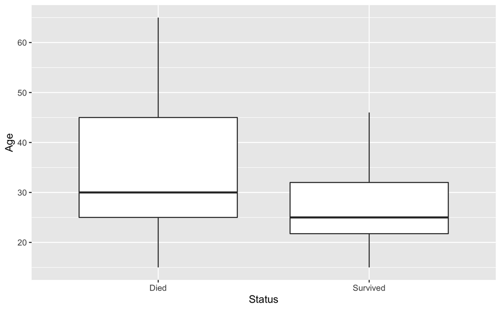

```r
# create a box plot between survival status and age
dt %>%
  ggplot() +
  geom_boxplot(aes(x = Status, y = Age))
```

```r
# summary
summary(dt)
```

```
      Age           Sex        Status             Survived
 Min.   :15.0   Female:15   Length:45          Min.   :0.0000
 1st Qu.:24.0   Male  :30   Class :character   1st Qu.:0.0000
 Median :28.0               Mode  :character   Median :0.0000
 Mean   :31.8                                  Mean   :0.4444
 3rd Qu.:40.0                                  3rd Qu.:1.0000
 Max.   :65.0                                  Max.   :1.0000
```

```r
table(dt$Status, dt$Sex)
```

```
           Female Male
  Died          5   20
  Survived     10   10
```

It seems clear that both age and gender have an effect on someone’s survival, how do we come up with a model that will let us explore this relationship?

One way to think about the problem - we can treat `Survived` and `Died` as successes and failures arising from a binomial distribution where the probability of a success is given by a transformation of a linear model of the predictors.

```r
# basic logistic regression model
lm <- glm(Survived ~ Age, data = dt, family = "binomial")
lm
```

```
Call:  glm(formula = Survived ~ Age, family = "binomial", data = dt)

Coefficients:
(Intercept)          Age
    1.81852     -0.06647

Degrees of Freedom: 44 Total (i.e. Null);  43 Residual
Null Deviance:      61.83
Residual Deviance: 56.29    AIC: 60.29
```

```r
summary(lm)
```

```
Call:
glm(formula = Survived ~ Age, family = "binomial", data = dt)

Deviance Residuals:
    Min       1Q   Median       3Q      Max
-1.5401  -1.1594  -0.4651   1.0842   1.7283

Coefficients:
            Estimate Std. Error z value Pr(>|z|)
(Intercept)  1.81852    0.99937   1.820   0.0688 .
Age         -0.06647    0.03222  -2.063   0.0391 *
---
Signif. codes:  0 ‘***’ 0.001 ‘**’ 0.01 ‘*’ 0.05 ‘.’ 0.1 ‘ ’ 1

(Dispersion parameter for binomial family taken to be 1)

    Null deviance: 61.827  on 44  degrees of freedom
Residual deviance: 56.291  on 43  degrees of freedom
AIC: 60.291

Number of Fisher Scoring iterations: 4
```

**Model**:

$$\log\left(\frac{p}{1-p}\right) = 1.8185-0.0665\times \text{Age}$$

Odds / Probability of survival for a newborn (`Age=0`):

$$\begin{aligned}
\log\left(\frac{p}{1-p}\right) &= 1.8185-0.0665\times \bf{0} \\
\frac{p}{1-p} &= \exp(1.8185) = 6.16 \\
p &= 6.16/7.16 = 0.86
\end{aligned}$$

```r
# prediction for a newborn
oddsAgeZero <- exp(predict(lm, list(Age=0)))
```

```r
# probability
oddsAgeZero / (1 + oddsAgeZero)
```

```
        1
0.8603882
```

Odds / Probability of survival for a 50 year old:

$$\begin{aligned}
\log\left(\frac{p}{1-p}\right) &= 1.8185-0.0665\times \bf{50}\\
\frac{p}{1-p} &= \exp(-1.5065) = 0.222 \\
p &= 0.222/1.222 = 0.181
\end{aligned}$$

```r
oddsAge <- exp(predict(lm, list(Age=50)))
oddsAge / (1 + oddsAge)
```

```
        1
0.1816816
```

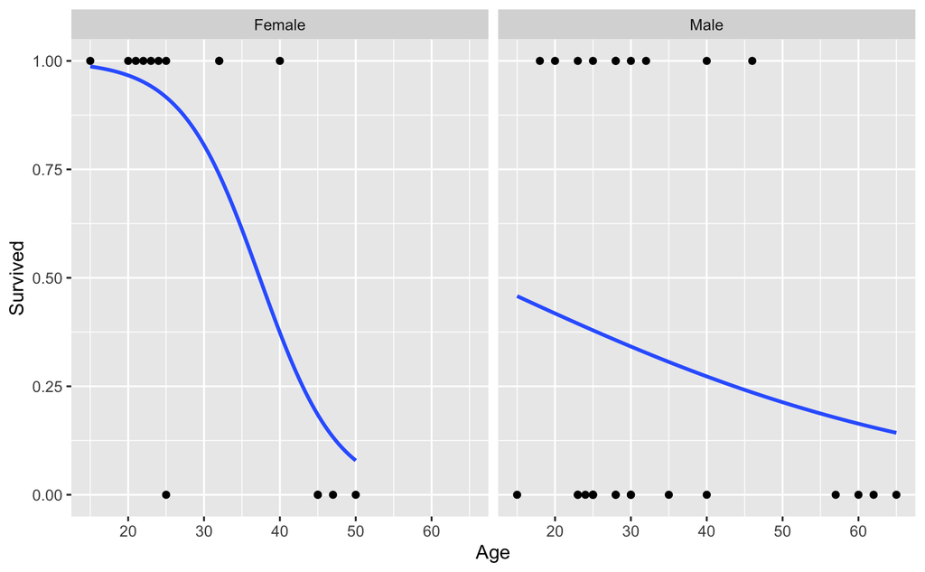

```r
# visualization
ggplot(dt, aes(x = Age, y = Survived)) +
  geom_point() +
  stat_smooth(method="glm", method.args=list(family="binomial"), se=FALSE) +
  facet_wrap(~Sex)
```

Visualization for the full model (without separation by gender)

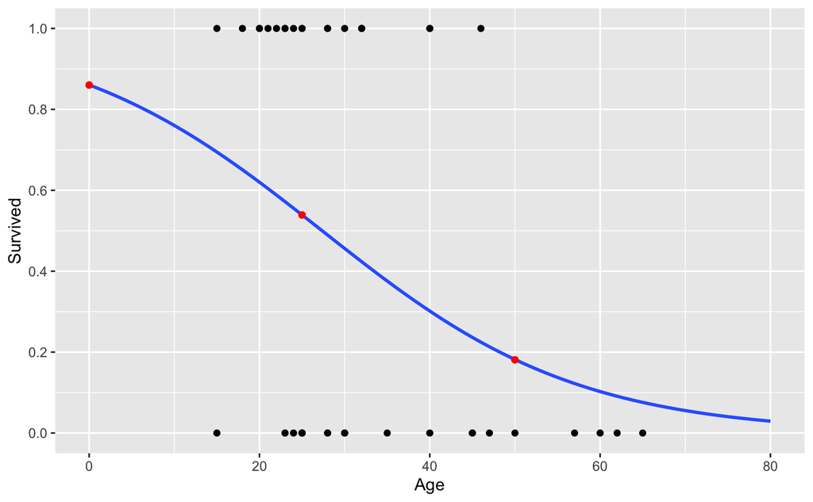

```r
# visualization
ggplot(dt, aes(x = Age, y = Survived)) +
  geom_point() +
  stat_smooth(method="glm", method.args=list(family="binomial"), se=FALSE, fullrange = TRUE) +
  scale_y_continuous(breaks = seq(0, 1, 0.2)) +
  xlim(0, 80) +
  geom_point(aes(x = 50, y = 0.181), color = "red") +
  geom_point(aes(x = 0,  y = 0.860), color = "red") +
  geom_point(aes(x = 25, y = 0.539), color = "red")
```

Total counts per `Sex`:

```r
# count
dt %>%
  group_by(Sex) %>%
  count()
```

| Sex | n |
| --- | --- |
| Female | 15 |
| Male | 30 |

```r
dt[, .N, by = Sex]
```

| Sex | N |
| --- | --- |
| Male | 30 |
| Female | 15 |

```r
# Multiple Logistic Regression Model
lm <- glm(Survived ~ Age + Sex, data = dt, family = "binomial")
lm
```

```
Call:  glm(formula = Survived ~ Age + Sex, family = "binomial", data = dt)

Coefficients:
(Intercept)          Age      SexMale
     3.2304      -0.0782      -1.5973

Degrees of Freedom: 44 Total (i.e. Null);  42 Residual
Null Deviance:      61.83
Residual Deviance: 51.26    AIC: 57.26
```

```r
summary(lm)
```

```
Call:
glm(formula = Survived ~ Age + Sex, family = "binomial", data = dt)

Deviance Residuals:
    Min       1Q   Median       3Q      Max
-1.7445  -1.0441  -0.3029   0.8877   2.0472

Coefficients:
            Estimate Std. Error z value Pr(>|z|)
(Intercept)  3.23041    1.38686   2.329   0.0198 *
Age         -0.07820    0.03728  -2.097   0.0359 *
SexMale     -1.59729    0.75547  -2.114   0.0345 *
---
Signif. codes:  0 ‘***’ 0.001 ‘**’ 0.01 ‘*’ 0.05 ‘.’ 0.1 ‘ ’ 1

(Dispersion parameter for binomial family taken to be 1)

    Null deviance: 61.827  on 44  degrees of freedom
Residual deviance: 51.256  on 42  degrees of freedom
AIC: 57.256

Number of Fisher Scoring iterations: 4
```

$$General Model:\\log\left(\frac{p}{1-p}\right) = 1.63312-0.0782\times \text{Age}+1.59729\times \text{Sex}\\
Female Model:\\log\left(\frac{p}{1-p}\right) = 1.63312-0.0782\times \text{Age}+1.59729\times \text{1}\\
= 3.23041-0.0782\times \text{Age}\\
Male Model:\\log\left(\frac{p}{1-p}\right) = 1.63312-0.0782\times \text{Age}+1.59729\times \text{0}\\
= 1.63312-0.0782\times \text{Age}\\$$
Prediction: Probability of Survival for 50 year old man

```r
oddsAge / (1 + oddsAge)
```

[output not shown]

Probability of Survival for 50 year old female

```r
oddsAge <- exp(predict(lm, list(Age=50, Sex="Female")))
oddsAge / (1 + oddsAge)
```

```
        1
0.3363082
```